# piloto

Alexis Rangel

2022-10-22

# RMARKDOWN DE GRAFICAS

## Cargando paquetes y base requeridos

#### ESTRUCTURA DE GGPLOT2

ggplot(data = DATOS) + GEOM_FUNCIÓN( mapping = aes(MAPEOS), stat = ESTADÍSTICAS, po- sition = POSICIÓN ) + FUNCIÓN_COORDENADAS + FUNCIÓN_FACETAS

```r
setwd("~/Maestria/Curso propedeutico/coloquio/ColoquioMAEA")
#estableciendo directorio
library(readr)
library(ggplot2)
library(tidyr)
library(readxl)
library(dplyr)
#file.choose()
ruta_db = "./DBS/Default of Credit Card Clients Dataset/UCI_Credit_Card.csv"

df1 = read.csv(ruta_db)
```

## Examinando el objeto

```r
class(df1) #verificando que sea un df
```

```
## [1] "data.frame"
```

```r
head(df1) #cabeza de df
```

|  | ID | LIMIT_BAL | SEX | EDUCATION | MARRIAGE | AGE | PAY_0 | PAY_2 | PAY_3 | PAY_4 | PAY_5 | PAY_6 | BILL_AMT1 | BILL_AMT2 | BILL_AMT3 | BILL_AMT4 | BILL_AMT5 | BILL_AMT6 | PAY_AMT1 | PAY_AMT2 | PAY_AMT3 | PAY_AMT4 | PAY_AMT5 | PAY_AMT6 | default.payment.next.month |
| --- | --- | --- | --- | --- | --- | --- | --- | --- | --- | --- | --- | --- | --- | --- | --- | --- | --- | --- | --- | --- | --- | --- | --- | --- | --- |
| 1 | 1 | 20000 | 2 | 2 | 1 | 24 | 2 | 2 | -1 | -1 | -2 | -2 | 3913 | 3102 | 689 | 0 | 0 | 0 | 0 | 689 | 0 | 0 | 0 | 0 | 1 |
| 2 | 2 | 120000 | 2 | 2 | 2 | 26 | -1 | 2 | 0 | 0 | 0 | 2 | 2682 | 1725 | 2682 | 3272 | 3455 | 3261 | 0 | 1000 | 1000 | 1000 | 0 | 2000 | 1 |
| 3 | 3 | 90000 | 2 | 2 | 2 | 34 | 0 | 0 | 0 | 0 | 0 | 0 | 29239 | 14027 | 13559 | 14331 | 14948 | 15549 | 1518 | 1500 | 1000 | 1000 | 1000 | 5000 | 0 |
| 4 | 4 | 50000 | 2 | 2 | 1 | 37 | 0 | 0 | 0 | 0 | 0 | 0 | 46990 | 48233 | 49291 | 28314 | 28959 | 29547 | 2000 | 2019 | 1200 | 1100 | 1069 | 1000 | 0 |
| 5 | 5 | 50000 | 1 | 2 | 1 | 57 | -1 | 0 | -1 | 0 | 0 | 0 | 8617 | 5670 | 35835 | 20940 | 19146 | 19131 | 2000 | 36681 | 10000 | 9000 | 689 | 679 | 0 |
| 6 | 6 | 50000 | 1 | 1 | 2 | 37 | 0 | 0 | 0 | 0 | 0 | 0 | 64400 | 57069 | 57608 | 19394 | 19619 | 20024 | 2500 | 1815 | 657 | 1000 | 1000 | 800 | 0 |

```r
str(df1) #generales del df
```

```
## 'data.frame':    30000 obs. of  25 variables:
##  $ ID                        : int  1 2 3 4 5 6 7 8 9 10 ...
##  $ LIMIT_BAL                 : num  20000 120000 90000 50000 50000 50000 500000 100000 140000 20000 ...
##  $ SEX                       : int  2 2 2 2 1 1 1 2 2 1 ...
##  $ EDUCATION                 : int  2 2 2 2 2 1 1 2 3 3 ...
##  $ MARRIAGE                  : int  1 2 2 1 1 2 2 2 1 2 ...
##  $ AGE                       : int  24 26 34 37 57 37 29 23 28 35 ...
##  $ PAY_0                     : int  2 -1 0 0 -1 0 0 0 0 -2 ...
##  $ PAY_2                     : int  2 2 0 0 0 0 0 -1 0 -2 ...
##  $ PAY_3                     : int  -1 0 0 0 -1 0 0 -1 2 -2 ...
##  $ PAY_4                     : int  -1 0 0 0 0 0 0 0 0 -2 ...
##  $ PAY_5                     : int  -2 0 0 0 0 0 0 0 0 -1 ...
##  $ PAY_6                     : int  -2 2 0 0 0 0 0 -1 0 -1 ...
##  $ BILL_AMT1                 : num  3913 2682 29239 46990 8617 ...
##  $ BILL_AMT2                 : num  3102 1725 14027 48233 5670 ...
##  $ BILL_AMT3                 : num  689 2682 13559 49291 35835 ...
##  $ BILL_AMT4                 : num  0 3272 14331 28314 20940 ...
##  $ BILL_AMT5                 : num  0 3455 14948 28959 19146 ...
##  $ BILL_AMT6                 : num  0 3261 15549 29547 19131 ...
##  $ PAY_AMT1                  : num  0 0 1518 2000 2000 ...
##  $ PAY_AMT2                  : num  689 1000 1500 2019 36681 ...
##  $ PAY_AMT3                  : num  0 1000 1000 1200 10000 657 38000 0 432 0 ...
##  $ PAY_AMT4                  : num  0 1000 1000 1100 9000 ...
##  $ PAY_AMT5                  : num  0 0 1000 1069 689 ...
##  $ PAY_AMT6                  : num  0 2000 5000 1000 679 ...
##  $ default.payment.next.month: int  1 1 0 0 0 0 0 0 0 0 ...
```

```r
names(df1) #columnas del df
```

```
##  [1] "ID"                         "LIMIT_BAL"
##  [3] "SEX"                        "EDUCATION"
##  [5] "MARRIAGE"                   "AGE"
##  [7] "PAY_0"                      "PAY_2"
##  [9] "PAY_3"                      "PAY_4"
## [11] "PAY_5"                      "PAY_6"
## [13] "BILL_AMT1"                  "BILL_AMT2"
## [15] "BILL_AMT3"                  "BILL_AMT4"
## [17] "BILL_AMT5"                  "BILL_AMT6"
## [19] "PAY_AMT1"                   "PAY_AMT2"
## [21] "PAY_AMT3"                   "PAY_AMT4"
## [23] "PAY_AMT5"                   "PAY_AMT6"
## [25] "default.payment.next.month"
```

```r
summary(df1) #estadisticas
```

```
##        ID          LIMIT_BAL            SEX          EDUCATION
##  Min.   :    1   Min.   :  10000   Min.   :1.000   Min.   :0.000
##  1st Qu.: 7501   1st Qu.:  50000   1st Qu.:1.000   1st Qu.:1.000
##  Median :15000   Median : 140000   Median :2.000   Median :2.000
##  Mean   :15000   Mean   : 167484   Mean   :1.604   Mean   :1.853
##  3rd Qu.:22500   3rd Qu.: 240000   3rd Qu.:2.000   3rd Qu.:2.000
##  Max.   :30000   Max.   :1000000   Max.   :2.000   Max.   :6.000
##     MARRIAGE          AGE            PAY_0             PAY_2
##  Min.   :0.000   Min.   :21.00   Min.   :-2.0000   Min.   :-2.0000
##  1st Qu.:1.000   1st Qu.:28.00   1st Qu.:-1.0000   1st Qu.:-1.0000
##  Median :2.000   Median :34.00   Median : 0.0000   Median : 0.0000
##  Mean   :1.552   Mean   :35.49   Mean   :-0.0167   Mean   :-0.1338
##  3rd Qu.:2.000   3rd Qu.:41.00   3rd Qu.: 0.0000   3rd Qu.: 0.0000
##  Max.   :3.000   Max.   :79.00   Max.   : 8.0000   Max.   : 8.0000
##      PAY_3             PAY_4             PAY_5             PAY_6
##  Min.   :-2.0000   Min.   :-2.0000   Min.   :-2.0000   Min.   :-2.0000
##  1st Qu.:-1.0000   1st Qu.:-1.0000   1st Qu.:-1.0000   1st Qu.:-1.0000
##  Median : 0.0000   Median : 0.0000   Median : 0.0000   Median : 0.0000
##  Mean   :-0.1662   Mean   :-0.2207   Mean   :-0.2662   Mean   :-0.2911
##  3rd Qu.: 0.0000   3rd Qu.: 0.0000   3rd Qu.: 0.0000   3rd Qu.: 0.0000
##  Max.   : 8.0000   Max.   : 8.0000   Max.   : 8.0000   Max.   : 8.0000
##    BILL_AMT1         BILL_AMT2        BILL_AMT3         BILL_AMT4
##  Min.   :-165580   Min.   :-69777   Min.   :-157264   Min.   :-170000
##  1st Qu.:   3559   1st Qu.:  2985   1st Qu.:   2666   1st Qu.:   2327
##  Median :  22382   Median : 21200   Median :  20088   Median :  19052
##  Mean   :  51223   Mean   : 49179   Mean   :  47013   Mean   :  43263
##  3rd Qu.:  67091   3rd Qu.: 64006   3rd Qu.:  60165   3rd Qu.:  54506
##  Max.   : 964511   Max.   :983931   Max.   :1664089   Max.   : 891586
##    BILL_AMT5        BILL_AMT6          PAY_AMT1         PAY_AMT2
##  Min.   :-81334   Min.   :-339603   Min.   :     0   Min.   :      0
##  1st Qu.:  1763   1st Qu.:   1256   1st Qu.:  1000   1st Qu.:    833
##  Median : 18104   Median :  17071   Median :  2100   Median :   2009
##  Mean   : 40311   Mean   :  38872   Mean   :  5664   Mean   :   5921
##  3rd Qu.: 50190   3rd Qu.:  49198   3rd Qu.:  5006   3rd Qu.:   5000
##  Max.   :927171   Max.   : 961664   Max.   :873552   Max.   :1684259
##     PAY_AMT3         PAY_AMT4         PAY_AMT5           PAY_AMT6
##  Min.   :     0   Min.   :     0   Min.   :     0.0   Min.   :     0.0
##  1st Qu.:   390   1st Qu.:   296   1st Qu.:   252.5   1st Qu.:   117.8
##  Median :  1800   Median :  1500   Median :  1500.0   Median :  1500.0
##  Mean   :  5226   Mean   :  4826   Mean   :  4799.4   Mean   :  5215.5
##  3rd Qu.:  4505   3rd Qu.:  4013   3rd Qu.:  4031.5   3rd Qu.:  4000.0
##  Max.   :896040   Max.   :621000   Max.   :426529.0   Max.   :528666.0
##  default.payment.next.month
##  Min.   :0.0000
##  1st Qu.:0.0000
##  Median :0.0000
##  Mean   :0.2212
##  3rd Qu.:0.0000
##  Max.   :1.0000
```

```r
length(df1) #largo del df1
```

```
## [1] 25
```

```r
dim(df1)
```

```
## [1] 30000    25
```

## ¿De qué trata mi base de datos? -Introducción

####Default Payments of Credit Card Clients in Taiwan from 2005 Esta base de datos cuenta con variables numericas y categoricas que describen la situación crediticia de personas con tarjetas de crédito en Taiwan en 2005

¿Qué variables vamos a usar? Todas. ID: ID of each client ####*Categoricas SEX: Gender (1=male, 2=female) EDUCATION: (1=graduate school, 2=university, 3=high school, 4=others, 5=unknown, 6=unknown) MARRIAGE: Marital status (1=married, 2=single, 3=others) AGE: Age in years

####*Numericas LIMIT_BAL: Amount of given credit in NT dollars (includes individual and family/supplementary credit PAY_0: Repayment status in September, 2005 (-1=pay duly, 1=payment delay for one month, 2=payment delay for two months, … 8=payment delay for eight months, 9=payment delay for nine months and above) PAY_2: Repayment status in August, 2005 (scale same as above) PAY_3: Repayment status in July, 2005 (scale same as above) PAY_4: Repayment status in June, 2005 (scale same as above) PAY_5: Repayment status in May, 2005 (scale same as above) PAY_6: Repayment status in April, 2005 (scale same as above) BILL_AMT1: Amount of bill statement in September, 2005 (NT dollar) BILL_AMT2: Amount of bill statement in August, 2005 (NT dollar) BILL_AMT3: Amount of bill statement in July, 2005 (NT dollar) BILL_AMT4: Amount of bill statement in June, 2005 (NT dollar) BILL_AMT5: Amount of bill statement in May, 2005 (NT dollar) BILL_AMT6: Amount of bill statement in April, 2005 (NT dollar) PAY_AMT1: Amount of previous payment in September, 2005 (NT dollar) PAY_AMT2: Amount of previous payment in August, 2005 (NT dollar) PAY_AMT3: Amount of previous payment in July, 2005 (NT dollar) PAY_AMT4: Amount of previous payment in June, 2005 (NT dollar) PAY_AMT5: Amount of previous payment in May, 2005 (NT dollar) PAY_AMT6: Amount of previous payment in April, 2005 (NT dollar) default.payment.next.month: Default payment (1=yes, 0=no)

¿De dónde sacamos la BD? https://www.kaggle.com/datasets/uciml/default-of-credit-card-clients-dataset

## INTRODUCCIÓN A GGPLOT

#### ANALISIS GRAFICO DESCRIPTIVO DE LA BASE DE DATOS

##### ¿Cuántos de los clientes son hombres y cuantos mujeres?

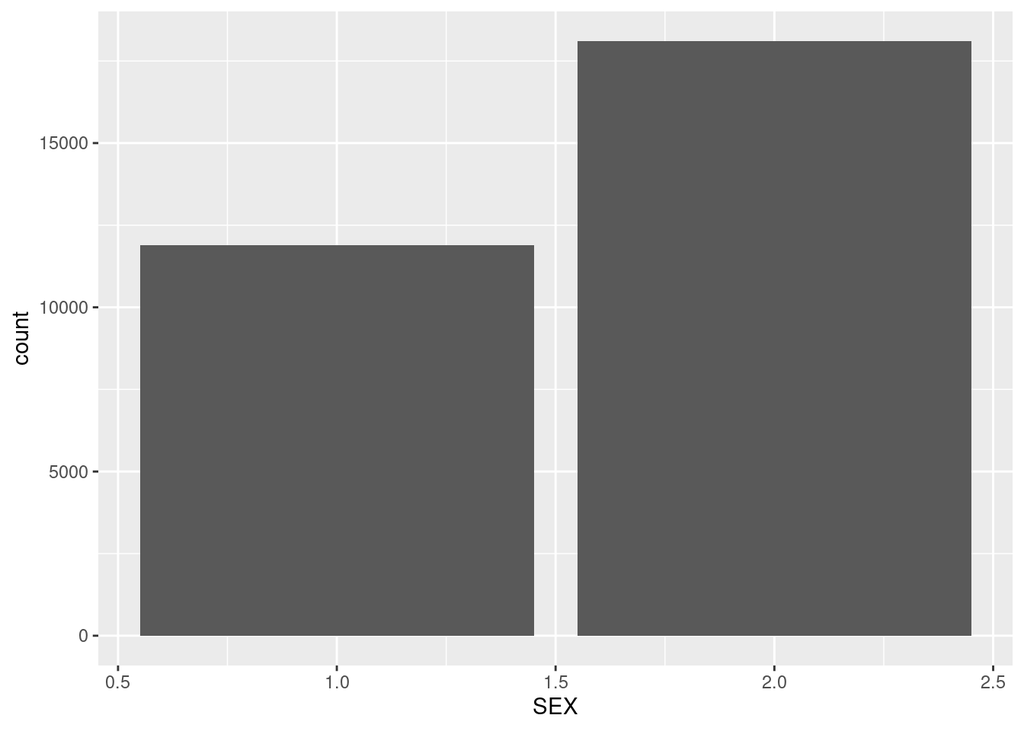

```r
#ggplot(data=df1)+
#  stat_count(mapping = aes(x=SEX))

ggplot(data=df1)+
  geom_bar(mapping = aes(SEX))
```

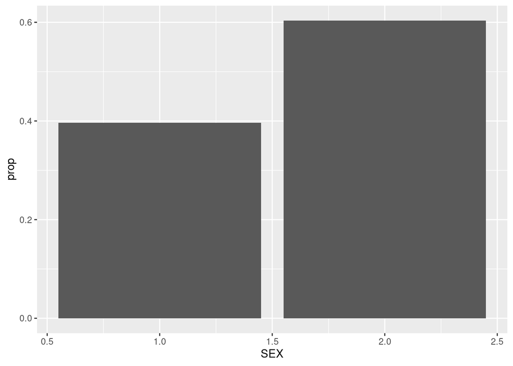

```r
ggplot(data=df1)+
  geom_bar(mapping = aes(x=SEX, y=..prop.., group=1))
```

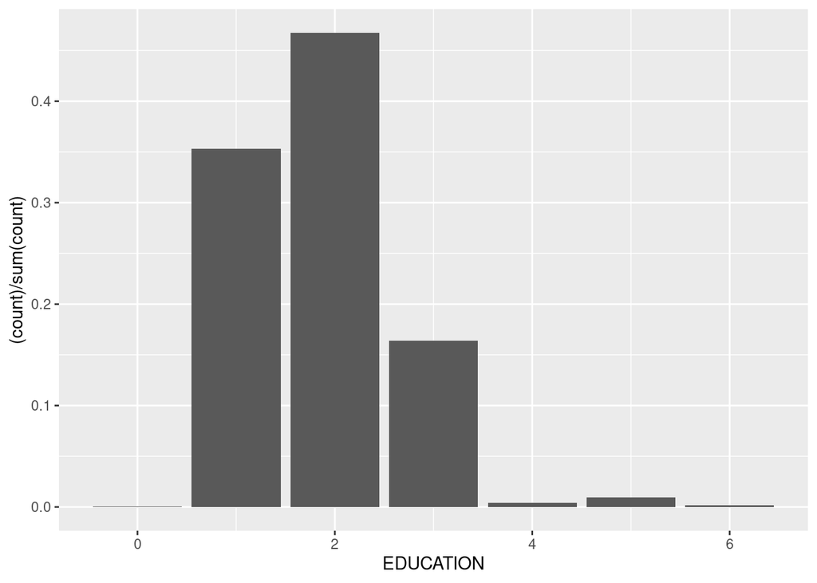

```r
##### ¿Cómo se distribuyen por educación?

ggplot(data=df1, aes(x=EDUCATION)) +
      geom_bar(aes(y = (..count..)/sum(..count..)))
```

```r
#ggplot(data=df1)+
#  stat_count(mapping = aes(x=EDUCATION))
```

##### ¿Por edad?

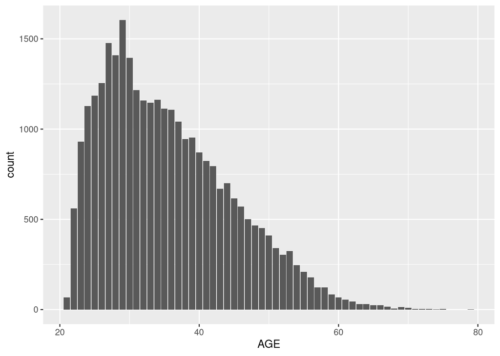

```r
ggplot(data=df1)+
  stat_count(mapping = aes(x=AGE))
```

##### ¿Por estado civil?

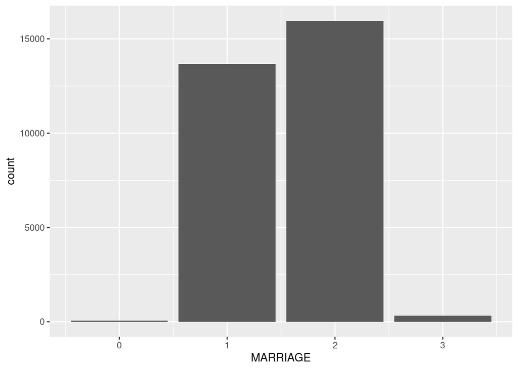

```r
ggplot(data=df1)+
  stat_count(mapping = aes(x=MARRIAGE))
```

#### Una gráfica basica que me muestre la relación entre la educación y el crédito total al que puede acceder´ el cliente

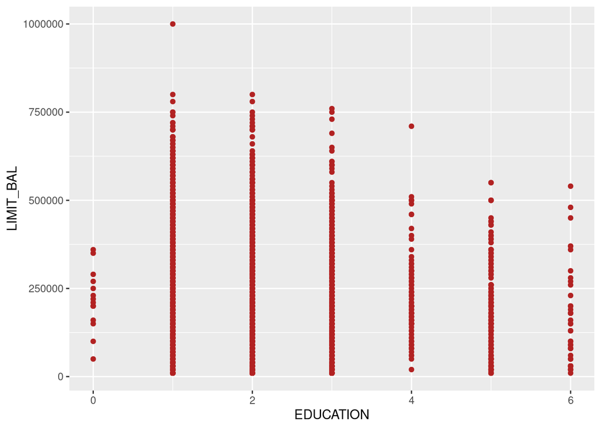

```r
#colnames(df1)
ggplot(data = df1) +
  geom_point(mapping = aes(x =EDUCATION, y =LIMIT_BAL ), color="firebrick")
```

#### Aplicando filtros simples al df

```r
# ¿Por qué hay valores en 0 en la columna EDUCATION?
df1_filtrado = df1[df1$EDUCATION == 0,]
vector_eduacion0 = df1[df1$EDUCATION == 0,]$EDUCATION
length(vector_eduacion0)
```

```
## [1] 14
```

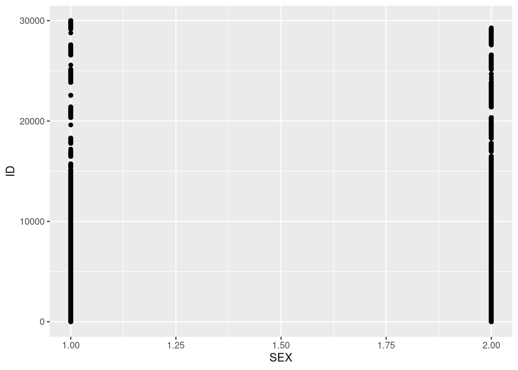

```r
df1$EDUCATION = as.factor(df1$EDUCATION)
ggplot(data = df1) +
  geom_point(mapping = aes(x =SEX, y =ID))
```

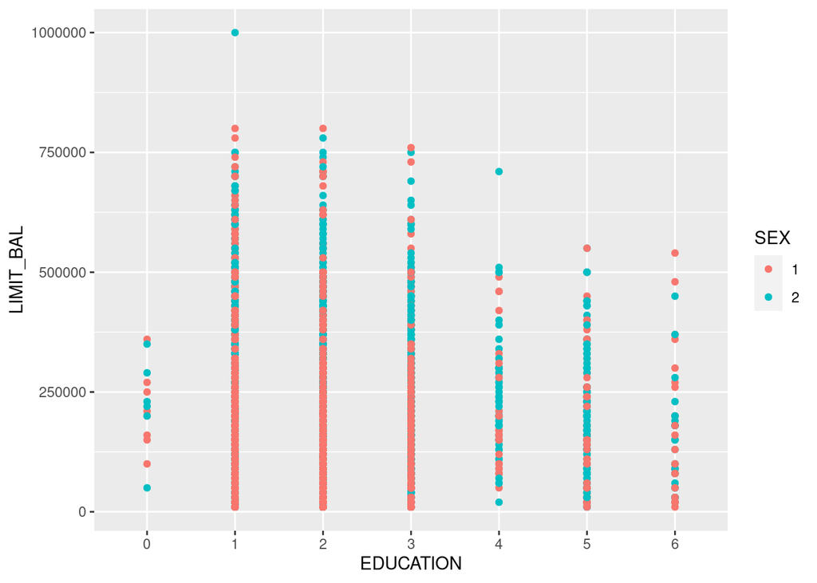

```r
df1$SEX = as.factor(df1$SEX) #Casteando la columna SEX a factor, dado que era un vector de integers
ggplot(data = df1) +
  geom_point(mapping = aes(x =EDUCATION, y =LIMIT_BAL, color=SEX))
```

En general cualquier indicación que se encuentre fuera de la función aes modificará todos los puntos de la misma manera, mientras que si se encuentra dentro de la función aes cambiará la estética en relación al contenido de una variable. Esta variable debe ser indicada, como por ejemplo color=tipo_empleo

```r
#ENcontrando valores unicos en un vector
vector_sex = df1[df1$SEX,]$SEX;unique(vector_sex)
```

```
## [1] 2
## Levels: 1 2
```

```r
table(df1$SEX) # contando cuantas mujeres y hombres hay en la base de datos -> (1=male, 2=female)
```

```
##
##     1     2
## 11888 18112
```

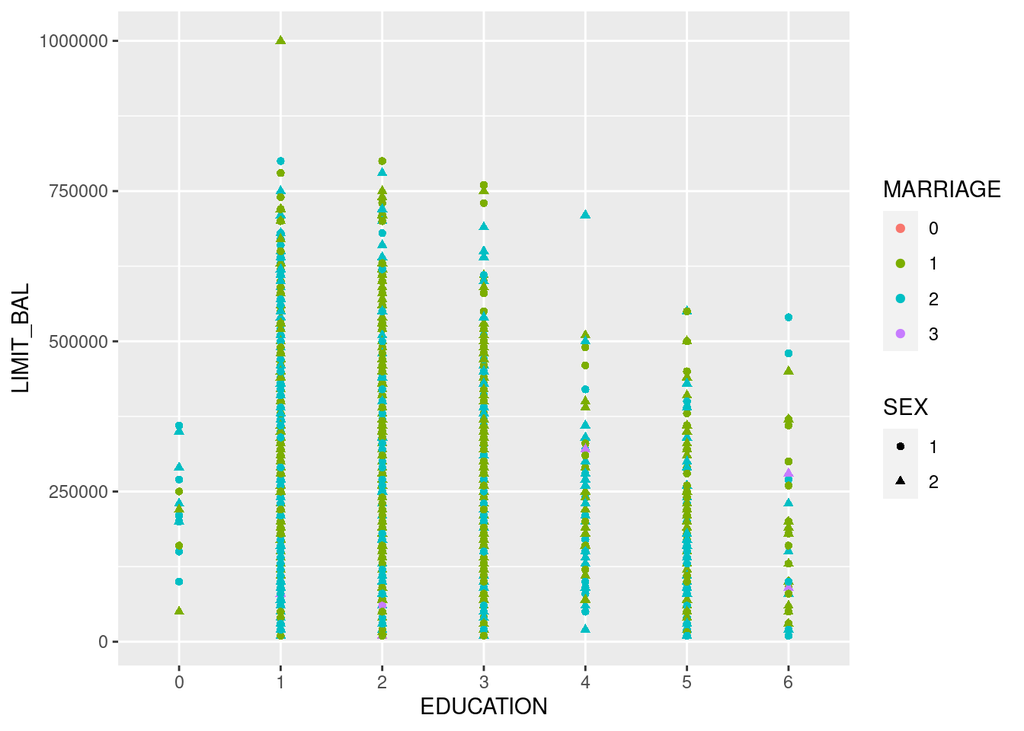

```r
df1$MARRIAGE = as.factor(df1$MARRIAGE)
ggplot(data = df1) +
  geom_point(mapping = aes(x =EDUCATION, y =LIMIT_BAL, color=MARRIAGE, shape= SEX))
```

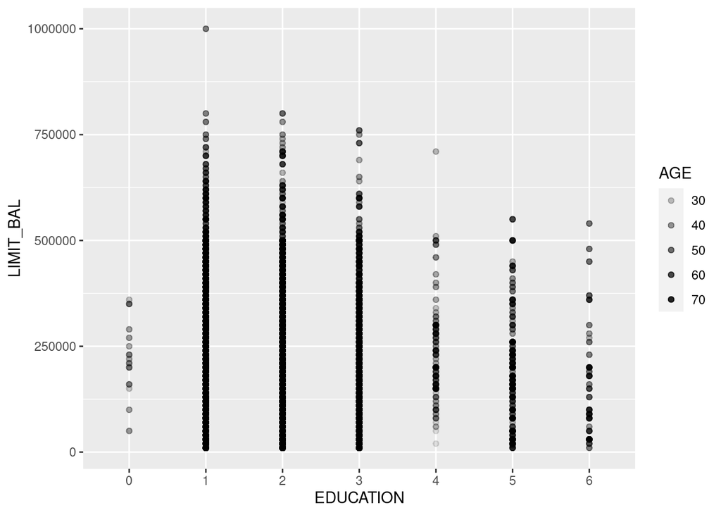

```r
ggplot(data = df1) +
  geom_point(mapping = aes(x =EDUCATION, y =LIMIT_BAL, alpha=AGE))
```

###Generando subplots

Observando la relación entre el monto maximo de crédito y la edad del cliente, aislados por sexo

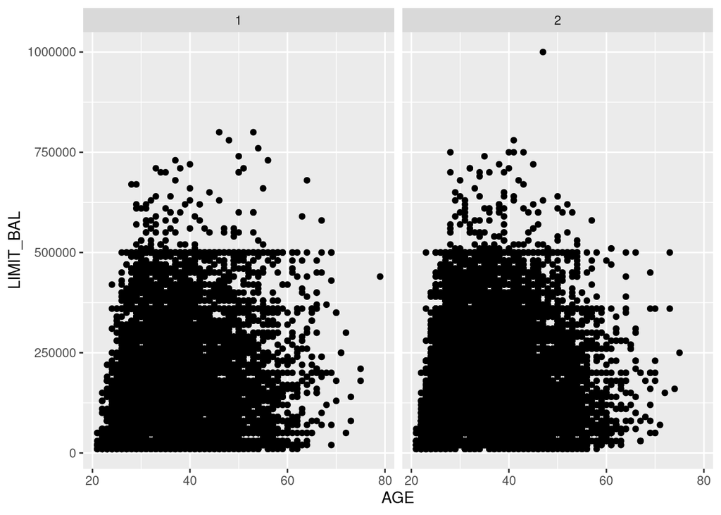

```r
#Usando facet_wrap para separar por variables categoricas
ggplot(data=df1)+
  geom_point(mapping = aes(x =AGE, y =LIMIT_BAL))+
  facet_wrap(~SEX, nrow=1, ncol=2)
```

```r
table(df1$MARRIAGE) #num de observaciones por categoria
```

```
##
##     0     1     2     3
##    54 13659 15964   323
```

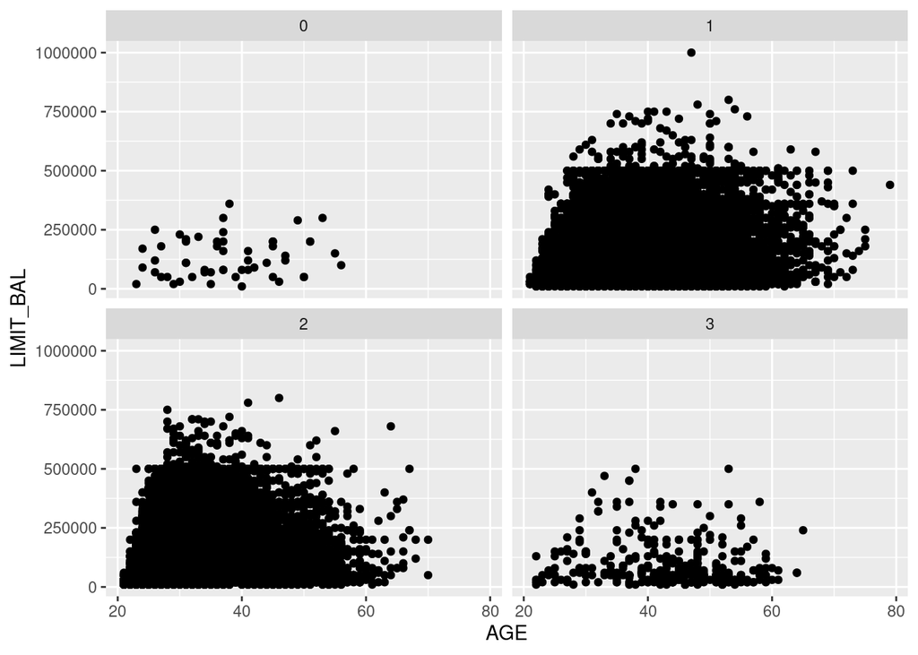

```r
ggplot(data=df1)+
  geom_point(mapping = aes(x =AGE, y =LIMIT_BAL))+
  facet_wrap(~MARRIAGE, nrow=2, ncol=2)
```

```r
#Marital status (1=married, 2=single, 3=others)

colnames(df1)
```

```
##  [1] "ID"                         "LIMIT_BAL"
##  [3] "SEX"                        "EDUCATION"
##  [5] "MARRIAGE"                   "AGE"
##  [7] "PAY_0"                      "PAY_2"
##  [9] "PAY_3"                      "PAY_4"
## [11] "PAY_5"                      "PAY_6"
## [13] "BILL_AMT1"                  "BILL_AMT2"
## [15] "BILL_AMT3"                  "BILL_AMT4"
## [17] "BILL_AMT5"                  "BILL_AMT6"
## [19] "PAY_AMT1"                   "PAY_AMT2"
## [21] "PAY_AMT3"                   "PAY_AMT4"
## [23] "PAY_AMT5"                   "PAY_AMT6"
## [25] "default.payment.next.month"
```

```r
table(df1$MARRIAGE)
```

```
##
##     0     1     2     3
##    54 13659 15964   323
```

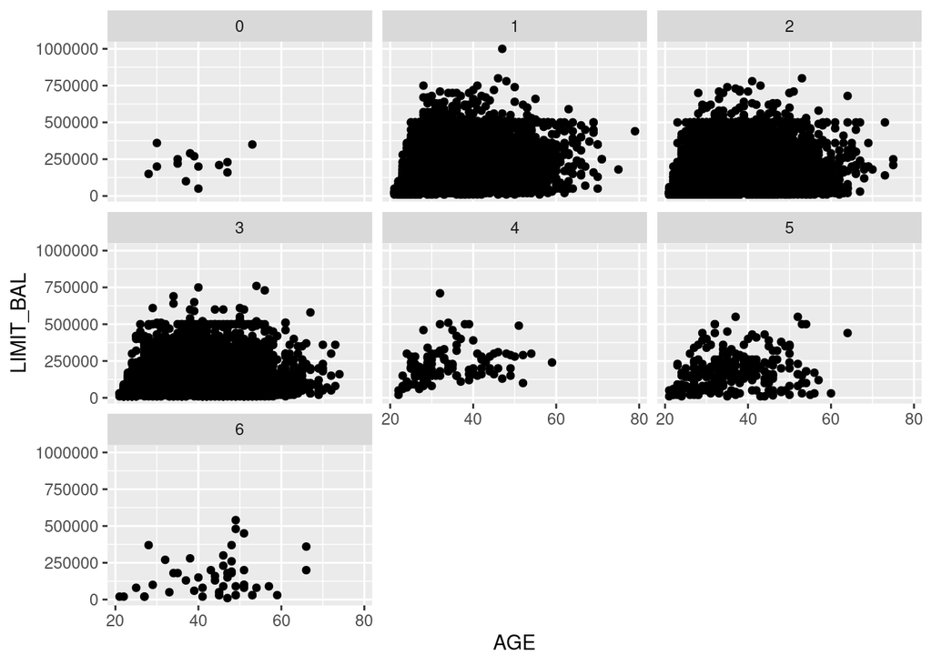

```r
ggplot(data=df1)+
  geom_point(mapping = aes(x =AGE, y =LIMIT_BAL))+
  facet_wrap(~EDUCATION, nrow=3, ncol=3)
```

```r
#(1=graduate
#school, 2=university, 3=high school, 4=others, 5=unknown, 6=unknown)

unique(df1$EDUCATION)
```

```
## [1] 2 1 3 5 4 6 0
## Levels: 0 1 2 3 4 5 6
```

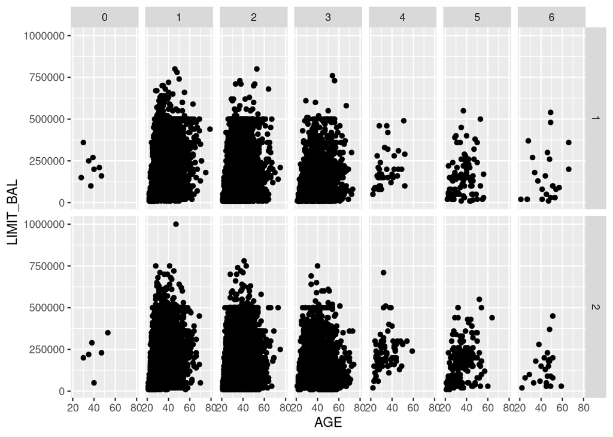

```r
ggplot(data=df1)+
  geom_point(mapping = aes(x =AGE, y =LIMIT_BAL))+
  facet_grid(SEX~EDUCATION)
```

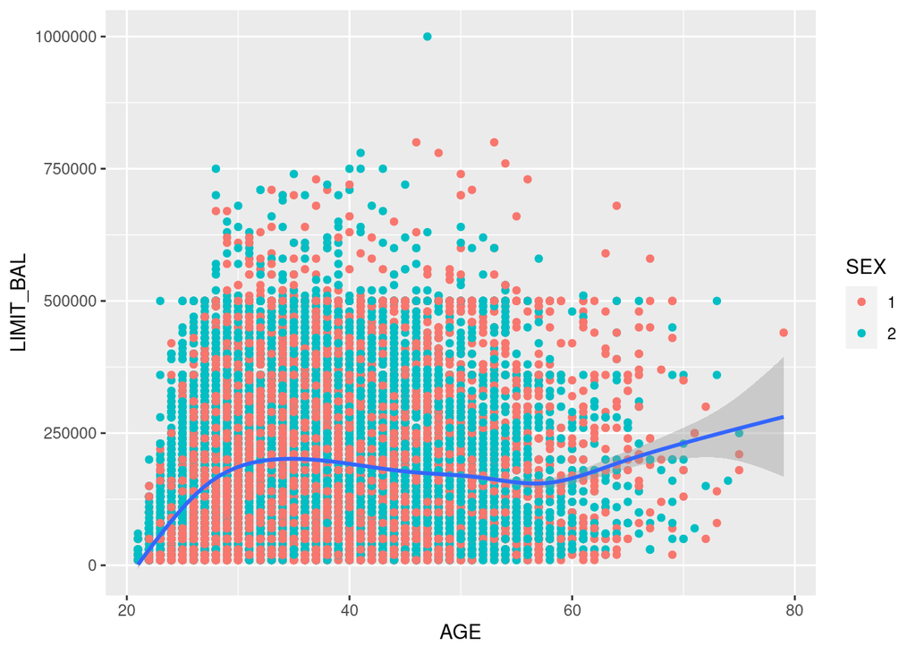

```r
ggplot(data=df1)+
  geom_point(mapping = aes(x =AGE, y =LIMIT_BAL, color=SEX))+
  geom_smooth(mapping = aes(x =AGE, y =LIMIT_BAL))
```

Pudiendo rescribir y acortar el chunk anterior como sigue, especificando las variables de los ejes y pasando como argumento las geometrias deseadas y sus particularidades

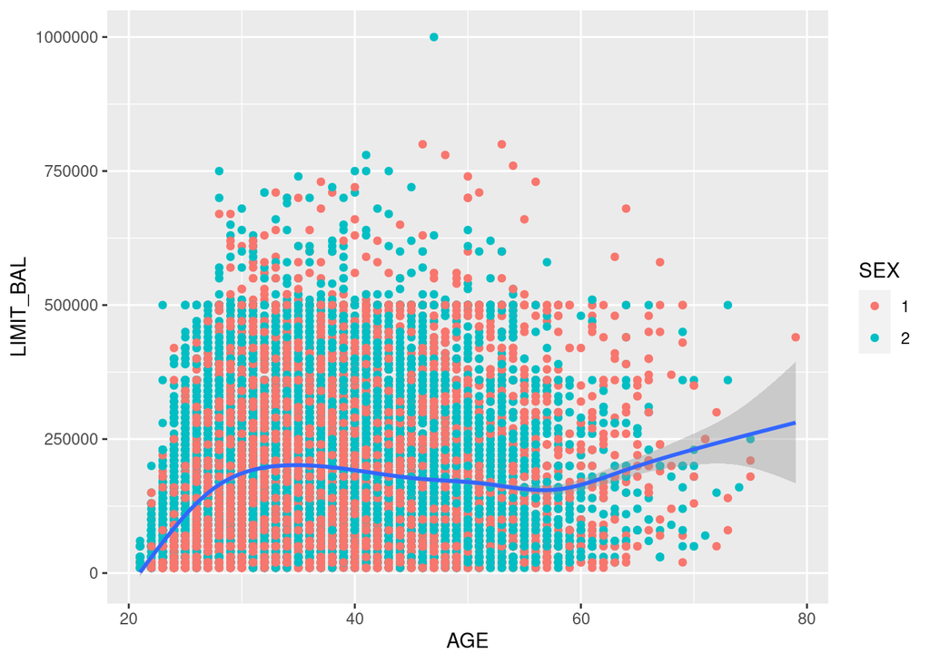

```r
ggplot(data=df1, mapping = aes(x =AGE, y
                                =LIMIT_BAL))+
geom_point(mapping = aes(color=SEX))+
  geom_smooth()
```

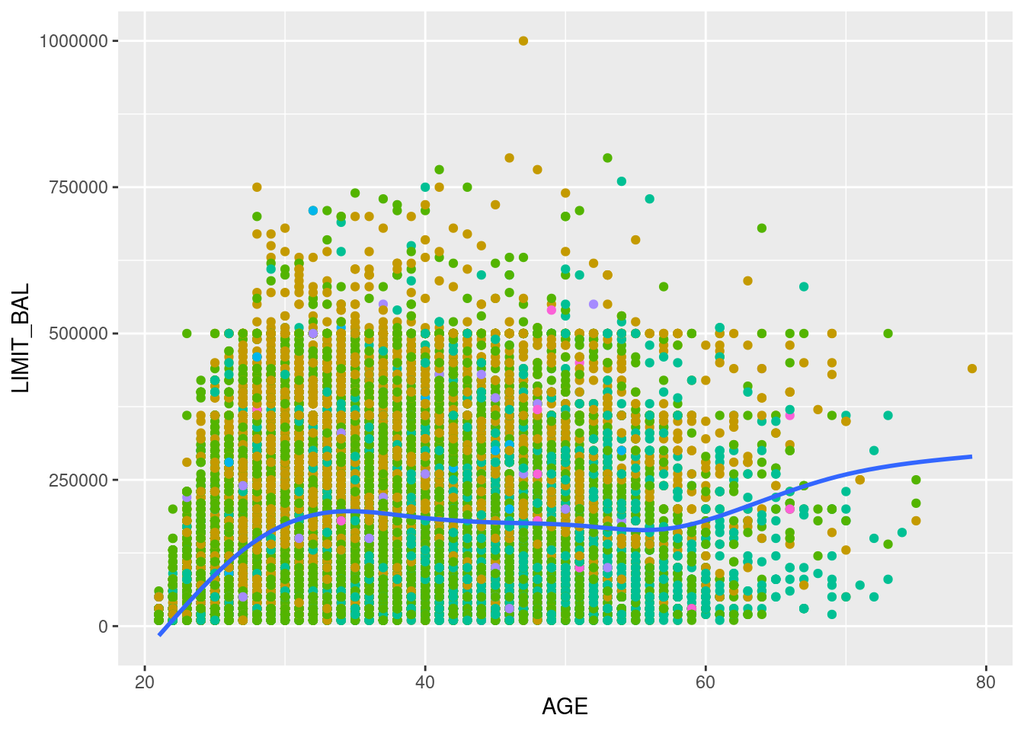

```r
ggplot(data=df1, mapping = aes(x =AGE, y
                                =LIMIT_BAL))+
geom_point(mapping = aes(color=EDUCATION), show.legend = FALSE)+
geom_smooth(
data=filter(df1, SEX==1), se=FALSE)
```

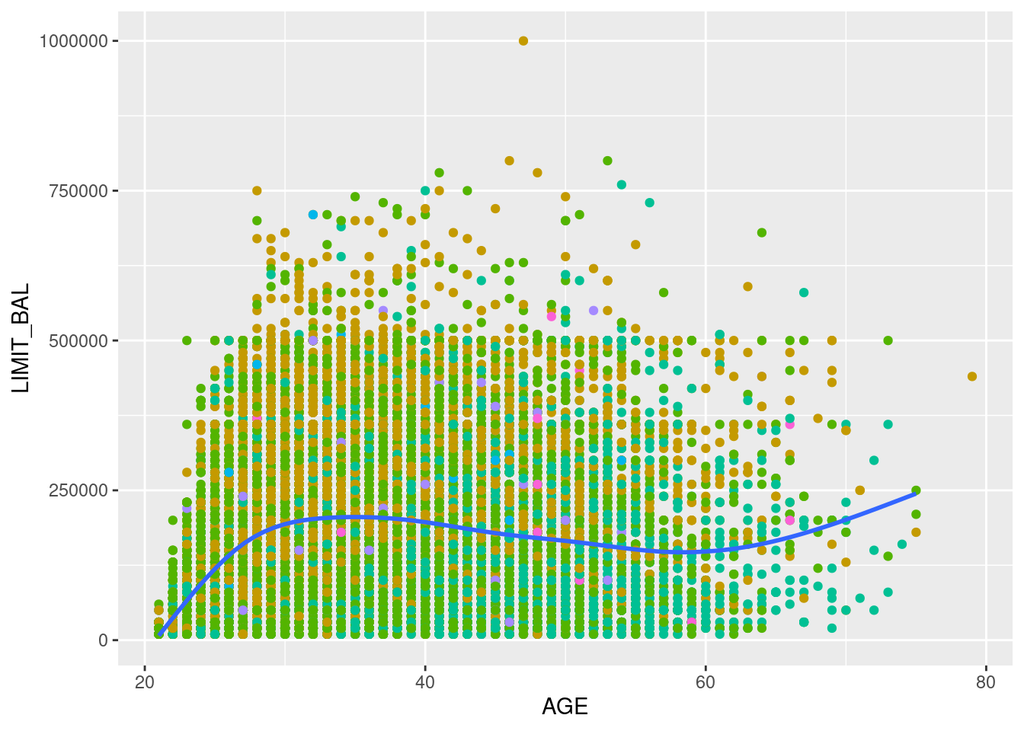

```r
ggplot(data=df1, mapping = aes(x =AGE, y
                                =LIMIT_BAL))+
geom_point(mapping = aes(color=EDUCATION), show.legend = FALSE)+
geom_smooth(
data=filter(df1, SEX==2), se=FALSE)
```

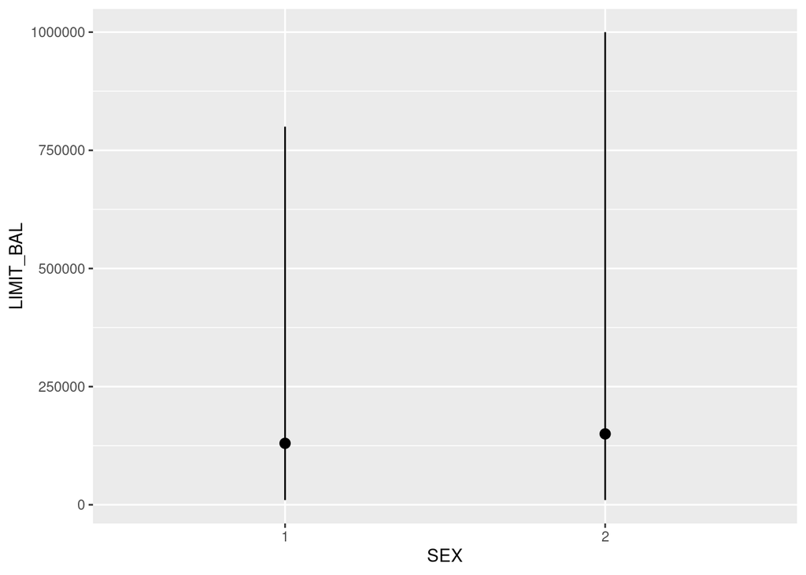

```r
#(1=male, 2=female)
ggplot(data=df1)+
stat_summary(
mapping = aes(x=SEX, y=LIMIT_BAL),
fun.min=min,
fun.max=max,
fun=median
)
```

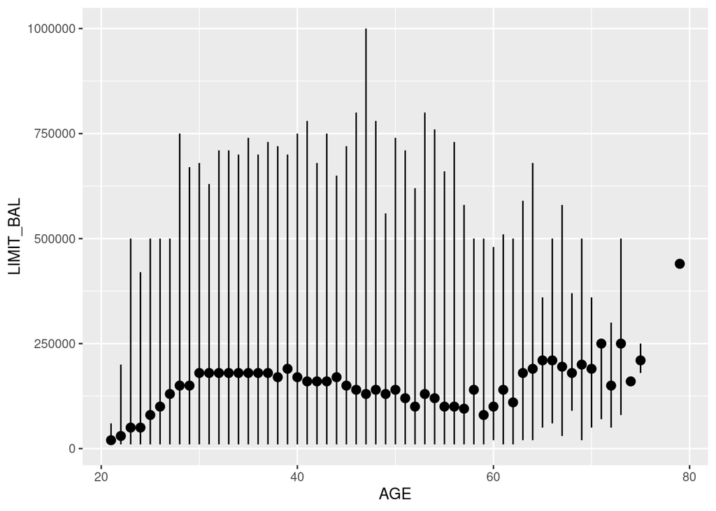

```r
ggplot(data=df1)+
stat_summary(
mapping = aes(x=AGE, y=LIMIT_BAL),
fun.min=min,
fun.max=max,
fun=median
)
```

// Por estado civil

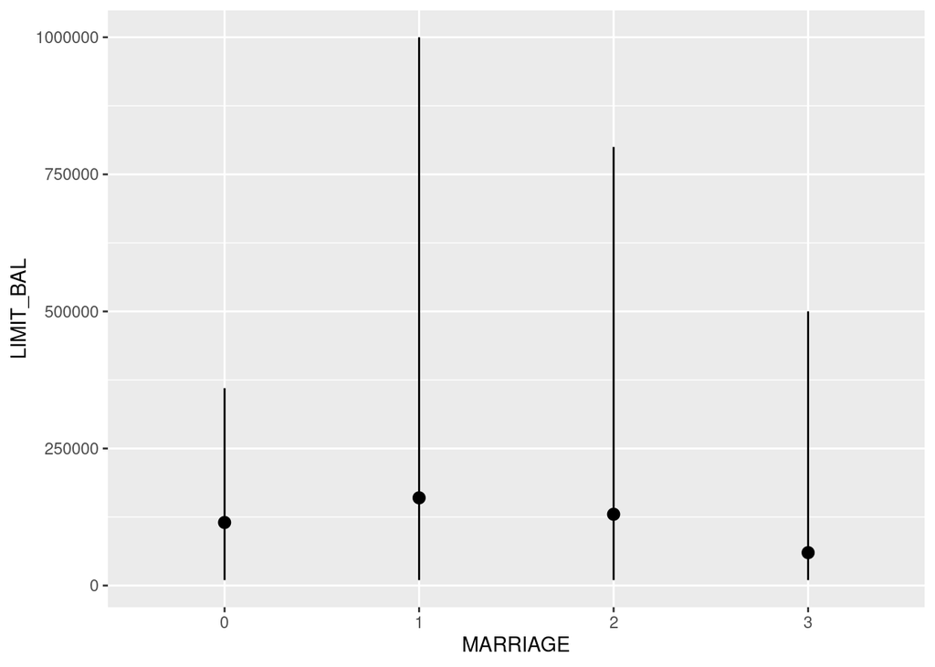

```r
#Marital status (1=married, 2=single, 3=others)
ggplot(data=df1)+
stat_summary(
mapping = aes(x=MARRIAGE, y=LIMIT_BAL),
fun.min=min,
fun.max=max,
fun=median
)
```

Distribución de estados civiles, por sexo

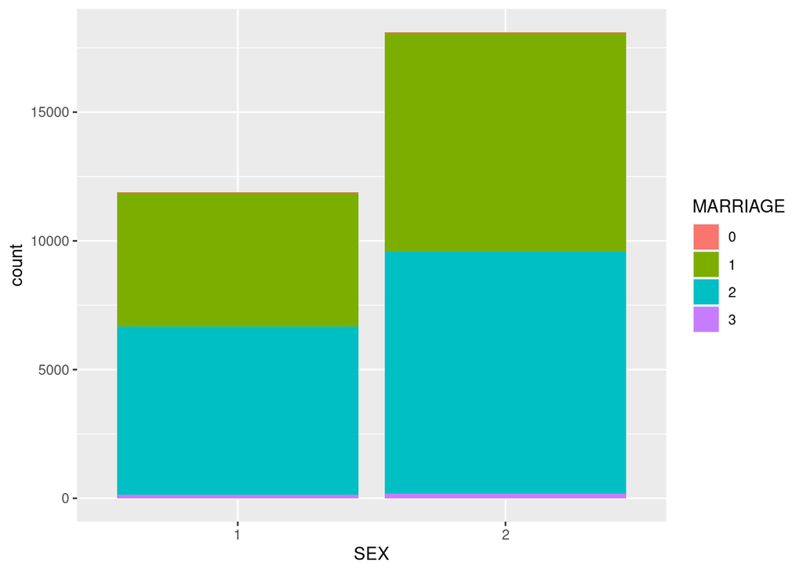

```r
ggplot(data=df1)+
geom_bar(mapping = aes(x=SEX, fill=MARRIAGE))
```

Distribución de educación por sexo

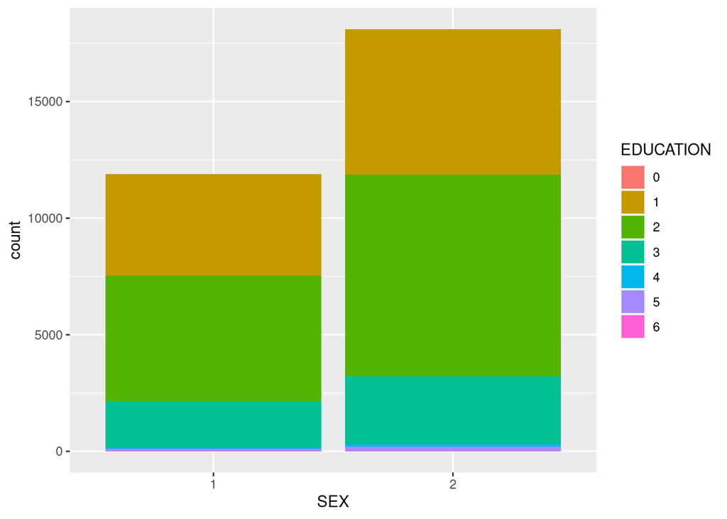

```r
ggplot(data=df1)+
geom_bar(mapping = aes(x=SEX, fill=EDUCATION))
```

```r
#, position = 'stack' >>> Automatico
#position=“identity”, "dodge", "fill".
```

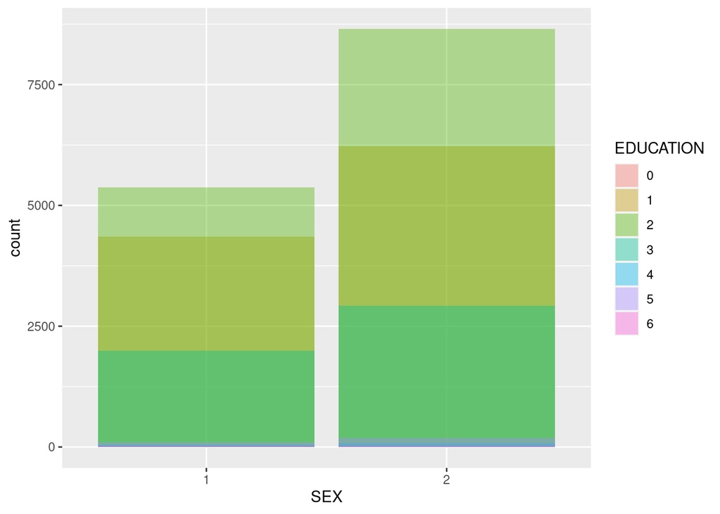

```r
ggplot(data=df1)+
geom_bar(mapping = aes(x=SEX, fill=EDUCATION), position = 'identity', alpha=2/5)
```

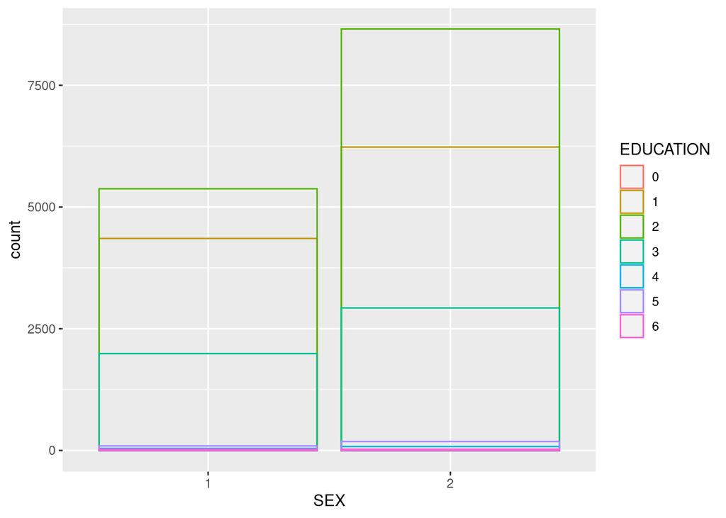

```r
ggplot(data=df1)+
geom_bar(mapping = aes(x=SEX, color=EDUCATION), position = 'identity', fill=NA)
```

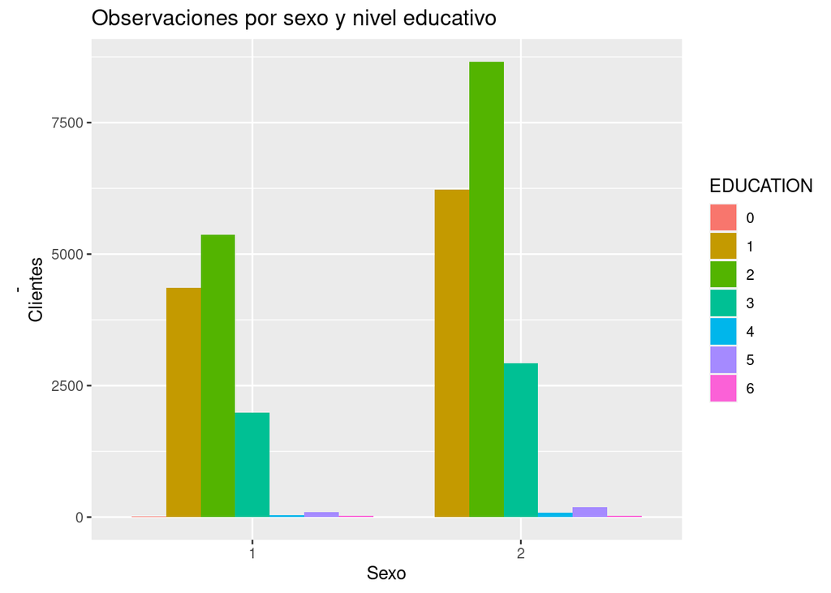

```r
ggplot(data=df1)+
geom_bar(mapping = aes(x=SEX, fill=EDUCATION), position = 'dodge')+
  labs(title="Observaciones por sexo y nivel educativo", x="Sexo", y="-
Clientes")
```

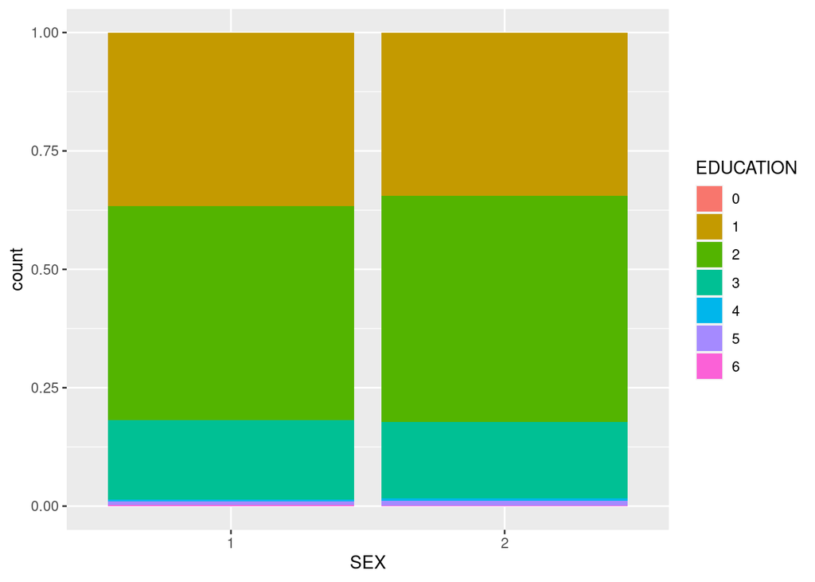

```r
#Midiendo proporciones
ggplot(data=df1)+
geom_bar(mapping = aes(x=SEX, fill=EDUCATION), position = 'fill')
```

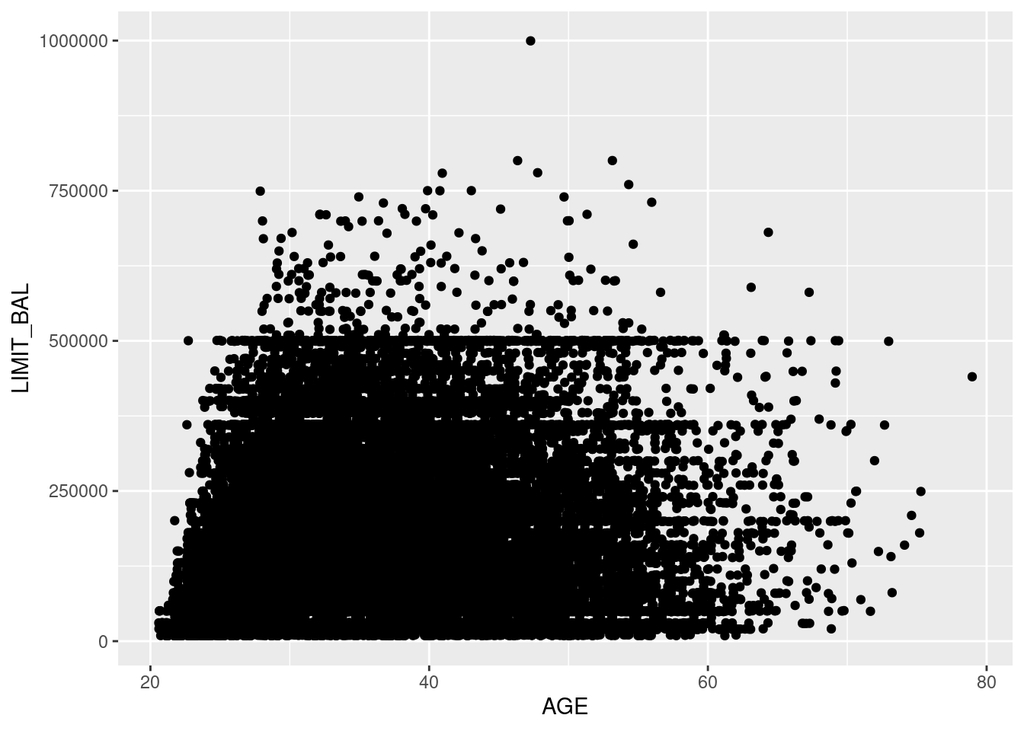

```r
ggplot(data = df1) +
geom_point(mapping = aes(x=AGE, y =LIMIT_BAL ), position =
"jitter")
```

Box plots

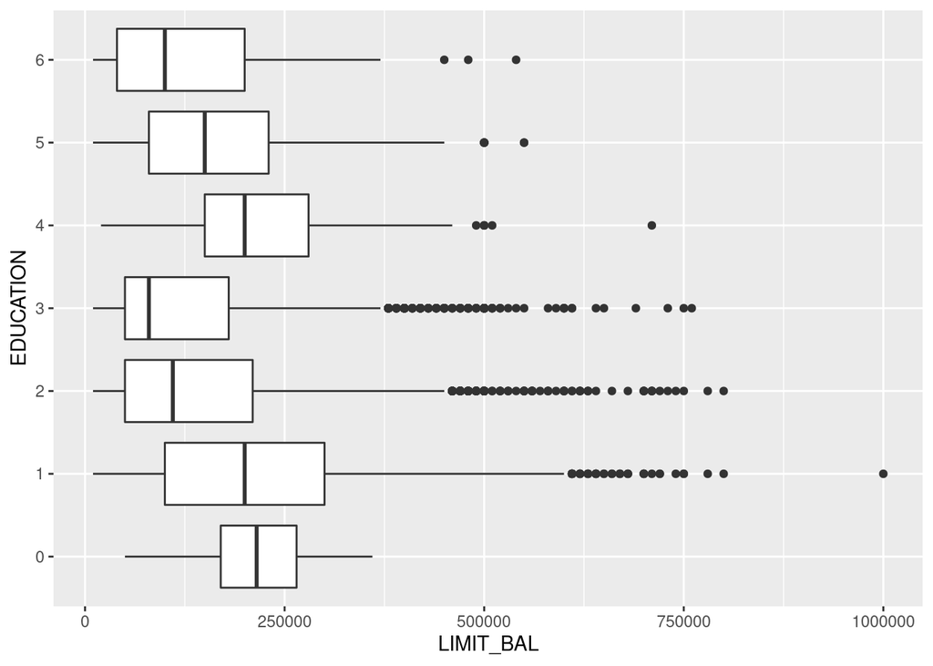

```r
ggplot(data=df1, mapping = aes(x=EDUCATION, y=LIMIT_BAL))+
geom_boxplot()+
coord_flip()
```